# Using R to do Raster analysis

Xu Jian

## Description

The data are landsat8 June to Augest one day image from 2013 to 2017. Choosing Binghamton as the Stuady Area Implement 1.Mask 2.Calculate NDVI 3.Extract Vegetation 4.Calculate Dense Vegetation Area If you want to analyze other Raster data, you just need to reset the list of the filepath and change the “n”

## Librarys

Using “raster”,“rgdal”,“UScensus2010”,“UScensus2010county”,“knitr”

```r
if(!require(raster)){install.packages("raster")}
library(raster)
if(!require(rgdal)){install.packages("rgdal")}
library(rgdal)
if(!require(UScensus2010)) {install.packages("UScensus2010")}
library(UScensus2010)
if(!require(UScensus2010county)) {install.county("osx")}
library(UScensus2010county)
if(!require(knitr)){install.packages("knitr")}
library(knitr)
```

## Define the function

### NDVI function

Define the function to calculate NDVI from land8 image

```r
ndvCalc <- function(x) {
  ndvi <- (x[[4]] - x[[3]]) / (x[[4]] + x[[3]])
  return(ndvi)
}
ndvOver <- function(x, y) {
  ndvi <- (y - x) / (x + y)
  return(ndvi)
}
```

### Vegetation function

Define the function to get the vegetation area and plot it

```r
getVegetation <- function(x){
  x[x < 0.2] <- NA
  return(x)
}
```

### Dense Vegetation function

Define the function to calculate the dense vegetation area

```r
getArea <- function(x){
  return(sum(x[x>=0.6])*res(x)[1]^2)
}
```

## Set work directory and list file

```r
listf <- list()
listf[1] <- "G:/R/FinalProject/data/land8_2017"
listf[2] <- "G:/R/FinalProject/data/lan8_2016"
listf[3] <- "G:/R/FinalProject/data/land8_2015"
listf[4] <- "G:/R/FinalProject/data/land8_2014"
listf[5] <- "G:/R/FinalProject/data/land8_2013"
listp <- list()
bandcom <- list()
n <- 5
for(i in 1:n){
  setwd(listf[[i]])
  getwd()
  listp[[i]] <- list.files(pattern= "*.TIF",full.names=TRUE)
  bandcom[[i]] <- stack(listp[[i]][4:9])
}
#### show landsat8 image in 2017 as an example
bandcom[[1]]
```

```
class       : RasterStack
dimensions  : 7941, 7811, 62027151, 6  (nrow, ncol, ncell, nlayers)
resolution  : 30, 30  (x, y)
extent      : 304485, 538815, 4503885, 4742115  (xmin, xmax, ymin, ymax)
coord. ref. : +proj=utm +zone=18 +datum=WGS84 +units=m +no_defs +ellps=WGS84 +towgs84=0,0,0
names       : LC08_L1TP//8_01_T1_B2, LC08_L1TP//8_01_T1_B3, LC08_L1TP//8_01_T1_B4, LC08_L1TP//8_01_T1_B5, LC08_L1TP//8_01_T1_B6, LC08_L1TP//8_01_T1_B7
min values  :                     0,                     0,                     0,                     0,                     0,                     0
max values  :                 65535,                 65535,                 65535,                 65535,                 65535,                 65535
```

```r
names(bandcom[[1]])
```

```
[1] "LC08_L1TP_015031_20170721_20170728_01_T1_B2"
[2] "LC08_L1TP_015031_20170721_20170728_01_T1_B3"
[3] "LC08_L1TP_015031_20170721_20170728_01_T1_B4"
[4] "LC08_L1TP_015031_20170721_20170728_01_T1_B5"
[5] "LC08_L1TP_015031_20170721_20170728_01_T1_B6"
[6] "LC08_L1TP_015031_20170721_20170728_01_T1_B7"
```

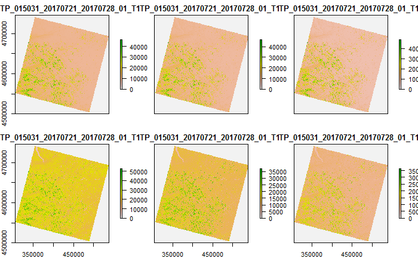

```r
plot(bandcom[[1]])
```

## Reprojection Rasters

reproject all the Raster layers into one Projection(including extents)

```r
newbandcom <- list()
for(i in 1:5){
  newbandcom[[i]] <-  projectRaster(bandcom[[i]],bandcom[[1]])
}
```

## Shapefile

Get the broome county shapefile

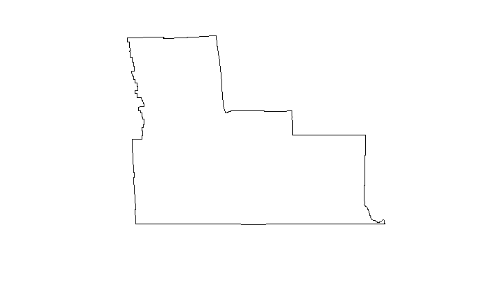

```r
data("new_york.county10")
shp_NY <- new_york.county10
df_NY <- shp_NY@data
broome <- df_NY$NAME10 == "Broome"
shp_Broome <- shp_NY[broome,]
plot(shp_Broome)
```

```r
shp_Broome
```

```
class       : SpatialPolygonsDataFrame
features    : 1
extent      : -76.13018, -75.35958, 41.99779, 42.4157  (xmin, xmax, ymin, ymax)
coord. ref. : +proj=longlat +ellps=GRS80 +datum=NAD83 +no_defs +towgs84=0,0,0
variables   : 462
names       : NAME10,    NAMELSAD10, state, county,  fips, P0010001, P0020001, P0020002, P0020003, P0020004, P0020005, P0020006, P0030001, P0030002, P0030003, ...
value       : Broome, Broome County,    36,    007, 36007,   200600,   200600,        0,        0,        0,        0,   200600,   200600,   176444,     9614, ...
```

## Reproject shapefile

```r
shp_BroomeUTM <- spTransform(shp_Broome, CRS(proj4string(bandcom[[1]])))
shp_BroomeUTM
```

```
class       : SpatialPolygonsDataFrame
features    : 1
extent      : 407004.3, 470220.2, 4649761, 4696294  (xmin, xmax, ymin, ymax)
coord. ref. : +proj=utm +zone=18 +datum=WGS84 +units=m +no_defs +ellps=WGS84 +towgs84=0,0,0
variables   : 462
names       : NAME10,    NAMELSAD10, state, county,  fips, P0010001, P0020001, P0020002, P0020003, P0020004, P0020005, P0020006, P0030001, P0030002, P0030003, ...
value       : Broome, Broome County,    36,    007, 36007,   200600,   200600,        0,        0,        0,        0,   200600,   200600,   176444,     9614, ...
```

## Raster Analysis

### Mask

```r
band_broome <- list()
for(i in 1:n){
  band_broome[[i]] <- mask(bandcom[[i]],shp_BroomeUTM)
}
```

### NDVI

Calculate NDVI in Broome using overlay()

```r
ndvi <- list()
for(i in 1:n){
  ndvi[[i]] <- overlay(x=band_broome[[i]][[3]], y=band_broome[[i]][[4]], fun=ndvOver)
}
```

### Vegetation

Extract the NDVI > 0.2 which is sparse vegetation and dense vegetation

```r
vegetation <- list()
for(i in 1:n){
  vegetation[[i]] <- getVegetation(ndvi[[i]])
}
```

### Dense Vegetation Area

Calculate the area of dense vegetation

```r
Dveg_Area <- list()
for(i in 1:n){
  Dveg_Area[i] <- getArea(ndvi[[i]])
}
area <- as.numeric(Dveg_Area)
year <- c("2017","2016","2015","2014","2013")
df <- data.frame(year,area)
kable(df)
```

| year | area |
| --- | --- |
| 2017 | 3170864 |
| 2016 | 14601905 |
| 2015 | 4916261 |
| 2014 | 149612299 |
| 2013 | 18581410 |

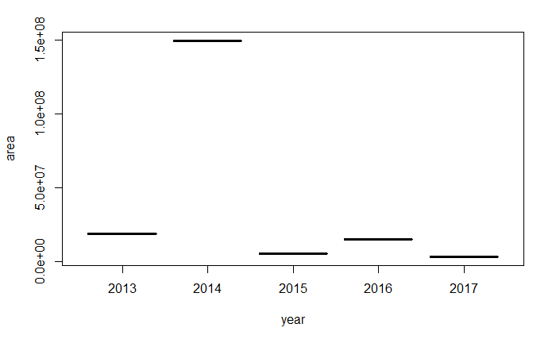

```r
plot(df,type = "b")
```

### Display ndvi plot and hist

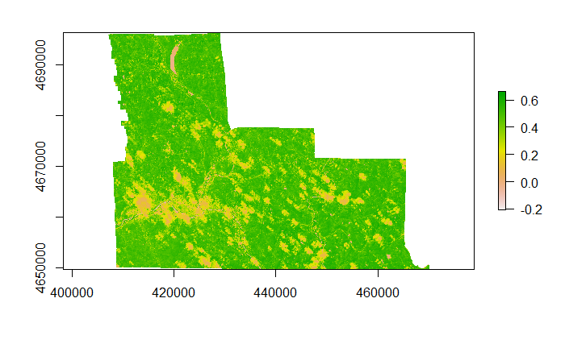

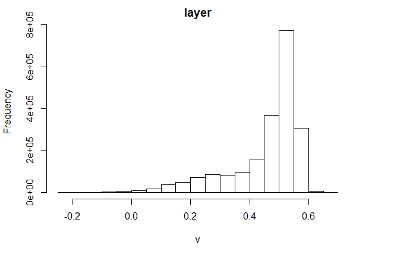

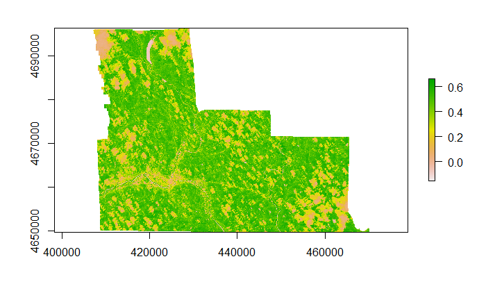

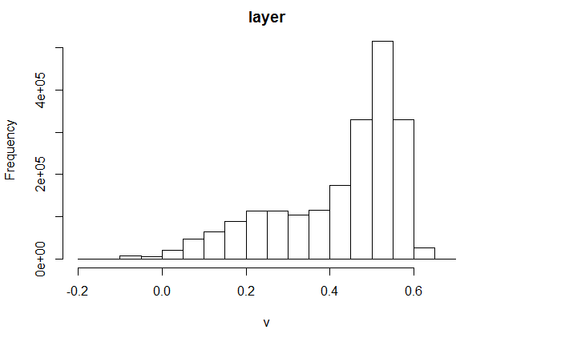

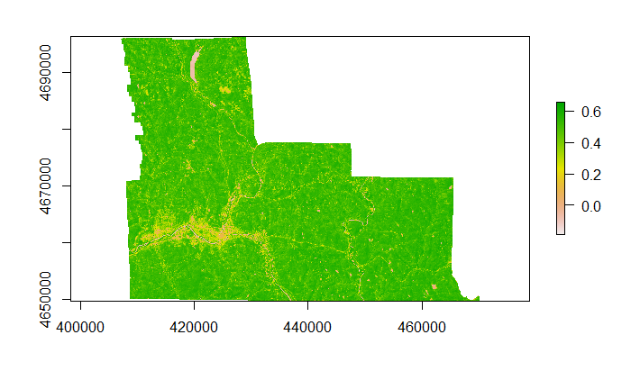

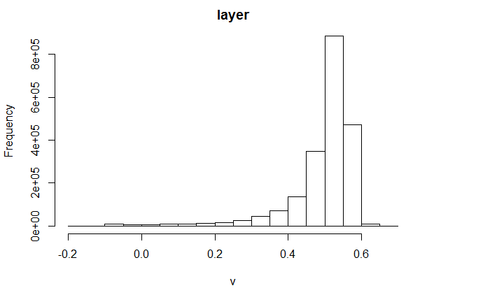

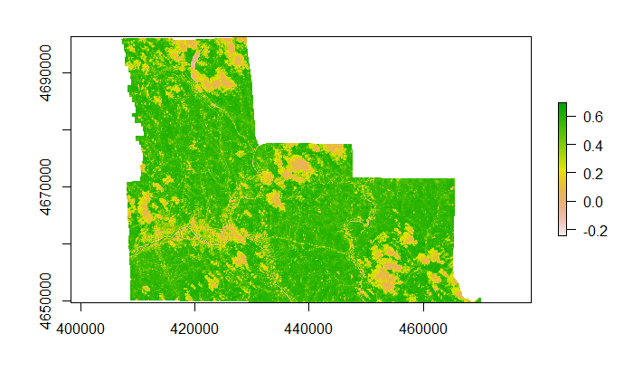

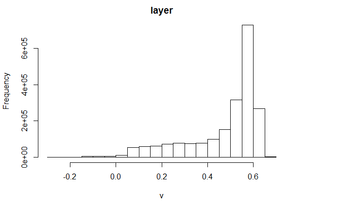

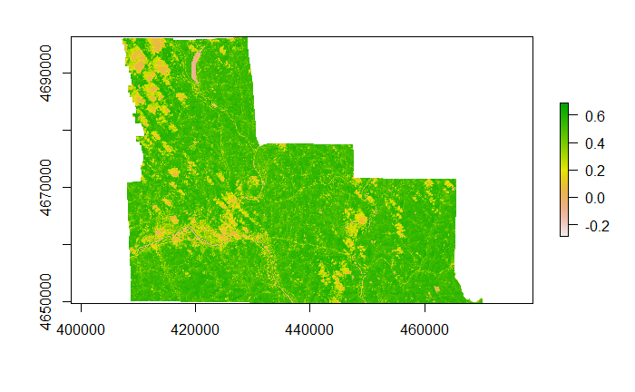

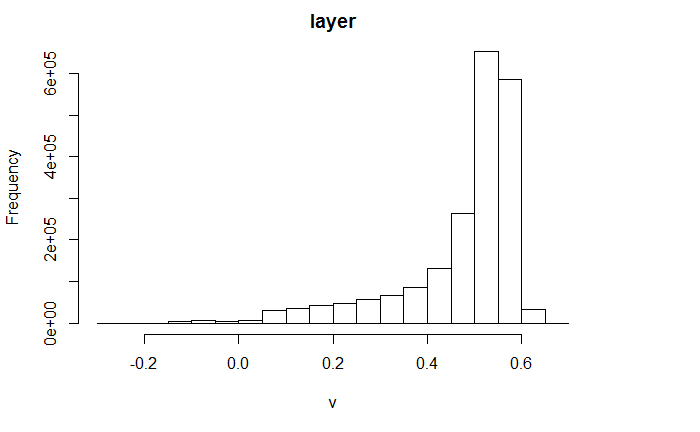

```r
for(i in 1:n){
  plot(ndvi[[i]],ext = shp_BroomeUTM)
hist(ndvi[[i]])
}
```

### Display vegetation

The layer1 to layer3 is 2017 to 2015 The layer1 to layer2 is 2014 to 2013

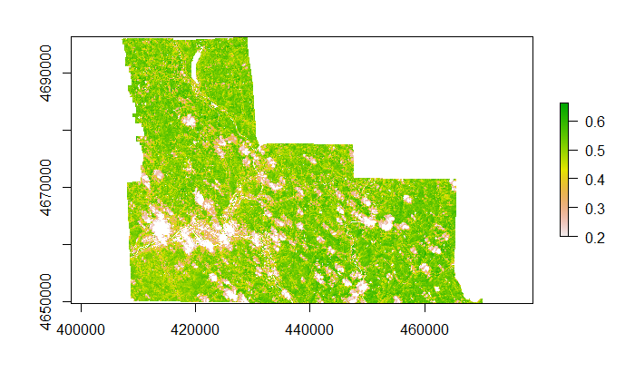

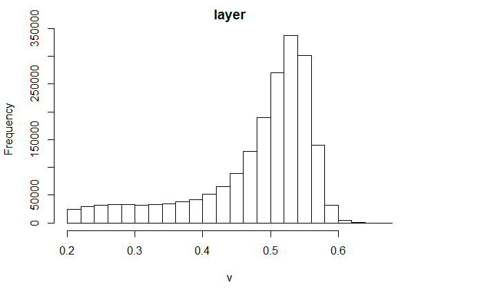

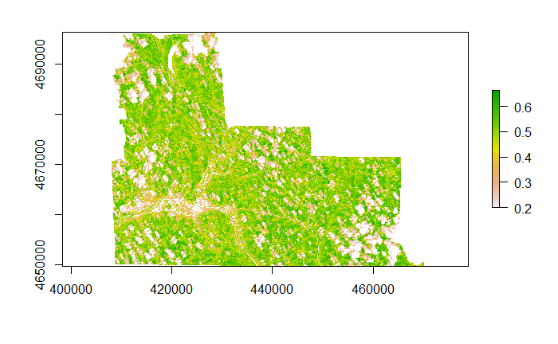

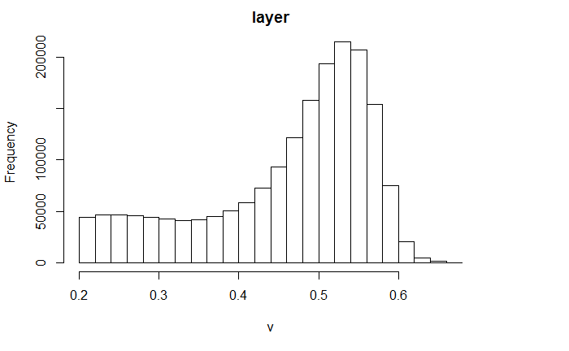

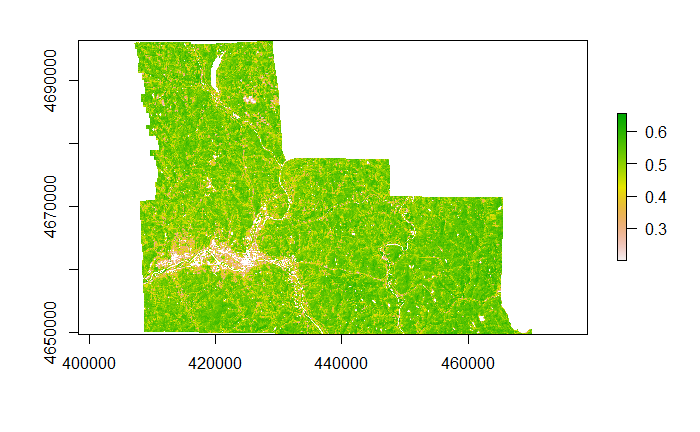

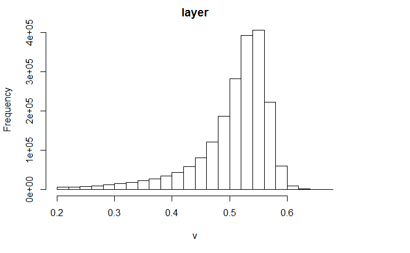

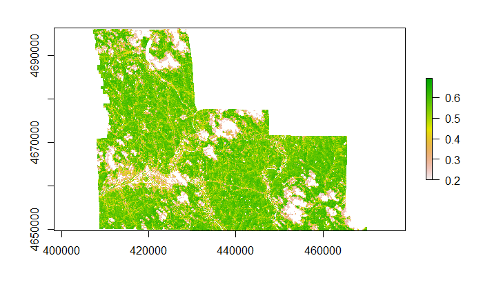

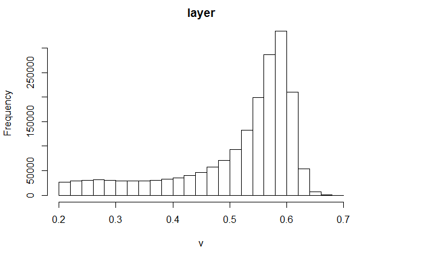

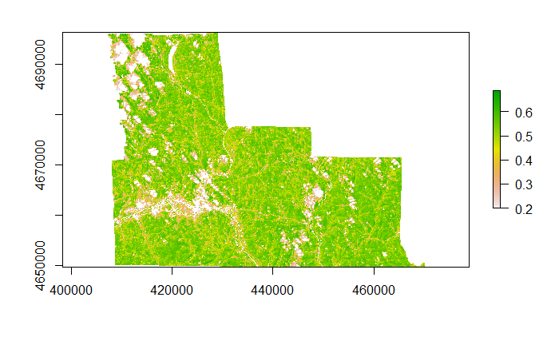

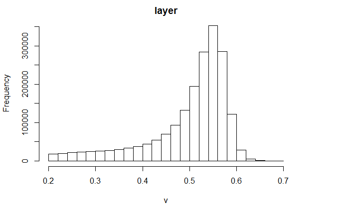

```r
# vege_show1 <- brick(vegetation[[1]],vegetation[[2]],vegetation[[3]])
# plot(vege_show1,ext = shp_BroomeUTM)
# hist(vege_show1)
# vege_show2 <- brick(vegetation[[4]],vegetation[[5]])
# plot(vege_show2,ext = shp_BroomeUTM)
# hist(vege_show2)
for(i in 1:n){
  plot(vegetation[[i]],ext = shp_BroomeUTM)
  hist(vegetation[[i]])
}
```